# Data analysis: Interpretation of statistical concepts in Psychology

Arnold Alejandro Tafur-Mendoza

Grupo de Estudios Avances en Medición Psicológica, Universidad Nacional Mayor de San Marcos  
aa.tafurm@up.edu.pe

Brian Norman Peña-Calero

Grupo de Estudios Avances en Medición Psicológica, Universidad Nacional Mayor de San Marcos  
brianmsm@gmail.com

Connie Daniela Aliaga Guanilo

Grupo de Estudios Avances en Medición Psicológica, Universidad Nacional Mayor de San Marcos  
connie.aliaga@unmsm.edu.pe

Christian Alexis Moreau Almaraz

Grupo de Estudios Avances en Medición Psicológica, Universidad Nacional Mayor de San Marcos  
christian.moreau@unmsm.edu.pe

Francesca Cecilia Ramírez-Bontá

Grupo de Estudios Avances en Medición Psicológica, Universidad Nacional Mayor de San Marcos  
francesca.ramirez.psico@gmail.com

Jackeline Edith Garcia-Serna

Grupo de Estudios Avances en Medición Psicológica, Universidad Nacional Mayor de San Marcos  
jackeline.garcia1@unmsm.edu.pe

Oscar Esteban Meza Chahuara

Grupo de Estudios Avances en Medición Psicológica, Universidad Nacional Mayor de San Marcos  
oscar.meza1@unmsm.edu.pe

13/2/2021

# 1 Data import

The database `data_base_program.csv` containing the information of the study participants is imported.

```r
base <- read_csv(here("data_base_program.csv"))
```

# 2 Data format

Only cases that have undergone both pretest and posttest measures at the same time are filtered out. Also, the scores of the reversed items are inverted.

```r
base <- base %>%
  filter(pretest == "yes",
         posttest == "yes") %>%
  mutate(
    across(
      c(pre_6, pre_8, pre_11, pre_13, pre_14, pre_17, pre_18,
        pre_20, pre_21, pre_22, pre_26, pre_27, pre_28, pre_29,
        post_6, post_8, post_11, post_13, post_14, post_17, post_18,
        post_20, post_21, post_22, post_26, post_27, post_28, post_29),
      ~ 6 - .x
    )
  ) %>%
  select(-c(1:6)) %>%
  select(pre_1, pre_2, pre_4, pre_5, pre_6, pre_8, pre_9,
         pre_11, pre_14, pre_17, pre_18, pre_22, post_1, post_2, post_4,
         post_5, post_6, post_8, post_9, post_11, post_14, post_14, post_17,
         post_18, post_22)

rmarkdown::paged_table(base)
```

| pre_1 | pre_2 | pre_4 | pre_5 | pre_6 | pre_8 | pre_9 | pre_11 | pre_14 | pre_17 | pre_18 | pre_22 | post_1 | post_2 | post_4 | post_5 | post_6 | post_8 | post_9 | post_11 | post_14 | post_17 | post_18 | post_22 |
| --- | --- | --- | --- | --- | --- | --- | --- | --- | --- | --- | --- | --- | --- | --- | --- | --- | --- | --- | --- | --- | --- | --- | --- |
| 4 | 3 | 2 | 3 | 4 | 3 | 2 | 3 | 3 | 3 | 2 | 4 | 5 | 4 | 2 | 4 | 2 | 4 | 2 | 3 | 2 | 2 | 1 | 5 |
| 3 | 4 | 2 | 5 | 2 | 3 | 3 | 3 | 2 | 4 | NA | 4 | 4 | 5 | 3 | 5 | 1 | 1 | 4 | 1 | 2 | 1 | 2 | 5 |
| 5 | 5 | 1 | 4 | 4 | 4 | 2 | 3 | 2 | 3 | 2 | 3 | 5 | 5 | 4 | 2 | 5 | 4 | 1 | 5 | 5 | 5 | 2 | 5 |
| 4 | 5 | 1 | NA | 5 | 4 | 4 | NA | 2 | 2 | 2 | 2 | 5 | 5 | 1 | 3 | 1 | NA | 5 | 3 | 4 | 5 | 1 | 1 |
| 5 | 5 | 2 | 4 | 2 | 2 | 4 | 4 | 4 | 2 | 2 | 2 | 5 | 5 | 2 | 2 | 2 | 3 | 4 | 4 | 4 | 2 | 2 | 4 |
| 5 | 5 | 2 | 3 | 2 | 3 | 4 | 2 | 5 | 2 | 3 | 2 | 5 | 5 | 4 | 2 | 4 | 3 | 2 | 3 | 2 | 3 | 4 | 2 |
| 5 | 1 | 2 | NA | 2 | NA | NA | 3 | 4 | NA | 3 | NA | 5 | 5 | 1 | 4 | 5 | 2 | 1 | 1 | 5 | 4 | 2 | 4 |
| 4 | 5 | 1 | 4 | 1 | 4 | NA | 2 | 5 | 2 | 1 | 4 | 4 | 5 | 3 | 1 | 5 | 5 | 1 | 5 | 5 | 5 | 1 | 5 |
| 3 | 4 | 3 | 1 | 2 | 2 | 2 | 1 | 3 | NA | 3 | 2 | 3 | 5 | 2 | 4 | 3 | 4 | 1 | 3 | 4 | 5 | 2 | 5 |

# 3 Descriptive statistics and hypothesis testing

The next code block generates the descriptive and group comparison measures using the Wilcoxon signed-rank test (W).

```r
describe(data.frame(base$post_1, base$pre_1), na.rm = F)[, c(2, 3, 4)]
```

```
##             n mean   sd
## base.post_1 9 4.56 0.73
## base.pre_1  9 4.22 0.83
```

```r
describe(data.frame(base$post_2, base$pre_2), na.rm = F)[, c(2, 3, 4)]
```

```
##             n mean   sd
## base.post_2 9 4.89 0.33
## base.pre_2  9 4.11 1.36
```

```r
describe(data.frame(base$post_4, base$pre_4), na.rm = F)[, c(2, 3, 4)]
```

```
##             n mean   sd
## base.post_4 9 2.44 1.13
## base.pre_4  9 1.78 0.67
```

```r
describe(data.frame(base$post_5, base$pre_5), na.rm = F)[, c(2, 3, 4)]
```

```
##             n mean   sd
## base.post_5 7 2.86 1.46
## base.pre_5  7 3.43 1.27
```

```r
describe(data.frame(base$post_6, base$pre_6), na.rm = F)[, c(2, 3, 4)]
```

```
##             n mean   sd
## base.post_6 9 3.11 1.69
## base.pre_6  9 2.67 1.32
```

```r
describe(data.frame(base$post_8, base$pre_8), na.rm = F)[, c(2, 3, 4)]
```

```
##             n mean   sd
## base.post_8 7 3.43 1.27
## base.pre_8  7 3.00 0.82
```

```r
describe(data.frame(base$post_9, base$pre_9), na.rm = F)[, c(2, 3, 4)]
```

```
##             n mean  sd
## base.post_9 7 2.71 1.6
## base.pre_9  7 3.00 1.0
```

```r
describe(data.frame(base$post_11, base$pre_11), na.rm = F)[, c(2, 3, 4)]
```

```
##              n mean   sd
## base.post_11 8 3.12 1.55
## base.pre_11  8 2.62 0.92
```

```r
describe(data.frame(base$post_14, base$pre_14), na.rm = F)[, c(2, 3, 4)]
```

```
##              n mean   sd
## base.post_14 9 3.67 1.32
## base.pre_14  9 3.33 1.22
```

```r
describe(data.frame(base$post_17, base$pre_17), na.rm = F)[, c(2, 3, 4)]
```

```
##              n mean   sd
## base.post_17 7 3.29 1.70
## base.pre_17  7 2.57 0.79
```

```r
describe(data.frame(base$post_18, base$pre_18), na.rm = F)[, c(2, 3, 4)]
```

```
##              n mean   sd
## base.post_18 8 1.88 0.99
## base.pre_18  8 2.25 0.71
```

```r
describe(data.frame(base$post_22, base$pre_22), na.rm = F)[, c(2, 3, 4)]
```

```
##              n mean   sd
## base.post_22 8 4.00 1.60
## base.pre_22  8 2.88 0.99
```

```r
wilcox.test(base$post_1, base$pre_1, paired = T)
```

```
##
##  Wilcoxon signed rank test with continuity correction
##
## data:  base$post_1 and base$pre_1
## V = 6, p-value = 0.1489
## alternative hypothesis: true location shift is not equal to 0
```

```r
wilcox.test(base$post_2, base$pre_2, paired = T)
```

```
##
##  Wilcoxon signed rank test with continuity correction
##
## data:  base$post_2 and base$pre_2
## V = 10, p-value = 0.08897
## alternative hypothesis: true location shift is not equal to 0
```

```r
wilcox.test(base$post_4, base$pre_4, paired = T)
```

```
##
##  Wilcoxon signed rank test with continuity correction
##
## data:  base$post_4 and base$pre_4
## V = 17, p-value = 0.2021
## alternative hypothesis: true location shift is not equal to 0
```

```r
wilcox.test(base$post_5, base$pre_5, paired = T)
```

```
##
##  Wilcoxon signed rank test with continuity correction
##
## data:  base$post_5 and base$pre_5
## V = 7, p-value = 0.5259
## alternative hypothesis: true location shift is not equal to 0
```

```r
wilcox.test(base$post_6, base$pre_6, paired = T)
```

```
##
##  Wilcoxon signed rank test with continuity correction
##
## data:  base$post_6 and base$pre_6
## V = 22, p-value = 0.6215
## alternative hypothesis: true location shift is not equal to 0
```

```r
wilcox.test(base$post_8, base$pre_8, paired = T)
```

```
##
##  Wilcoxon signed rank test with continuity correction
##
## data:  base$post_8 and base$pre_8
## V = 10.5, p-value = 0.4902
## alternative hypothesis: true location shift is not equal to 0
```

```r
wilcox.test(base$post_9, base$pre_9, paired = T)
```

```
##
##  Wilcoxon signed rank test with continuity correction
##
## data:  base$post_9 and base$pre_9
## V = 5, p-value = 0.5716
## alternative hypothesis: true location shift is not equal to 0
```

```r
wilcox.test(base$post_11, base$pre_11, paired = T)
```

```
##
##  Wilcoxon signed rank test with continuity correction
##
## data:  base$post_11 and base$pre_11
## V = 14, p-value = 0.5176
## alternative hypothesis: true location shift is not equal to 0
```

```r
wilcox.test(base$post_14, base$pre_14, paired = T)
```

```
##
##  Wilcoxon signed rank test with continuity correction
##
## data:  base$post_14 and base$pre_14
## V = 13.5, p-value = 0.5951
## alternative hypothesis: true location shift is not equal to 0
```

```r
wilcox.test(base$post_17, base$pre_17, paired = T)
```

```
##
##  Wilcoxon signed rank test with continuity correction
##
## data:  base$post_17 and base$pre_17
## V = 14.5, p-value = 0.4568
## alternative hypothesis: true location shift is not equal to 0
```

```r
wilcox.test(base$post_18, base$pre_18, paired = T)
```

```
##
##  Wilcoxon signed rank test with continuity correction
##
## data:  base$post_18 and base$pre_18
## V = 3, p-value = 0.233
## alternative hypothesis: true location shift is not equal to 0
```

```r
wilcox.test(base$post_22, base$pre_22, paired = T)
```

```
##
##  Wilcoxon signed rank test with continuity correction
##
## data:  base$post_22 and base$pre_22
## V = 25.5, p-value = 0.05783
## alternative hypothesis: true location shift is not equal to 0
```

# 4 Matched-pairs rank-biserial correlation

A function is created to calculate the matched-pairs rank-biserial correlation, which is the appropriate effect size measure for the analysis used.

```r
rc <- function(pretest, posttest){
  dif <- c(pretest - posttest)
  dif <- dif[which((dif != "NA") == TRUE)]
  dif <- dif[dif != 0]
  rangodif <- rank(abs(dif[dif != 0]))
  SumPos <- sum(rangodif[sign(dif) == 1])
  SumNeg <- sum(rangodif[sign(dif) == -1])
  t <- min(c( SumPos, SumNeg))
  n <- as.numeric(length(which((pretest != "NA" & posttest != "NA") == TRUE)))
  rc <- round(4*abs(t-(SumPos+SumNeg)/2)/(n*(n+1)),3)

  label <- paste(substitute(posttest)[3], "-", substitute(pretest)[3])
  tibble(Variables = label,
         'Matched-pairs rank-biserial correlation' = rc)
}
```

```r
bind_rows(
  rc(base$pre_1, base$post_1),
  rc(base$pre_2, base$post_2),
  rc(base$pre_4, base$post_4),
  rc(base$pre_5, base$post_5),
  rc(base$pre_6, base$post_6),
  rc(base$pre_8, base$post_8),
  rc(base$pre_9, base$post_9),
  rc(base$pre_11, base$post_11),
  rc(base$pre_14, base$post_14),
  rc(base$pre_17, base$post_17),
  rc(base$pre_18, base$post_18),
  rc(base$pre_22, base$post_22)
)
```

```
## # A tibble: 12 x 2
##    Variables        `Matched-pairs rank-biserial correlation`
##    <chr>                                                <dbl>
##  1 post_1 - pre_1                                       0.133
##  2 post_2 - pre_2                                       0.222
##  3 post_4 - pre_4                                       0.289
##  4 post_5 - pre_5                                       0.25
##  5 post_6 - pre_6                                       0.178
##  6 post_8 - pre_8                                       0.214
##  7 post_9 - pre_9                                       0.179
##  8 post_11 - pre_11                                     0.194
##  9 post_14 - pre_14                                     0.133
## 10 post_17 - pre_17                                     0.286
## 11 post_18 - pre_18                                     0.25
## 12 post_22 - pre_22                                     0.639
```

# 5 Plot

## 5.1 Preliminary format

A database containing the item score data from previous research is imported (Gordon, 2001; Mittag & Tompson, 2000; Monterde-i-Bort et al., 2010). This will be formatted in order to produce the comparative plot.

```r
comparison <- read_csv("base_comparison.csv")
names_items <- c("I. General perceptions",
                 "01. NHST controversy",
                 "02. Significance",
                 "03. Statistical power",
                 "04. p-value ban",
                 "05. Statistical significance",
                 "II. General Linear Model (GLM)",
                 "12. Correlation",
                 "26. Regression (*)",
                 "III. Stepwise analysis",
                 "13. Correct use (*)",
                 "20. Order of variables (*)",
                 "IV. Score reliability",
                 "07. Test reliability",
                 "19. NHST and reliability",
                 "23. Low reliability",
                 "28. Importance (*)",
                 "V. Type I and II errors",
                 "09. Type II error",
                 "17. Type I error (*)",
                 "22. Type I and II errors (*)",
                 "29. Frequency (*)",
                 "VI. Sample size influences",
                 "10. Small sample size",
                 "16. Reject Ho",
                 "25. Large sample size",
                 "VII. p-value (effect size)",
                 "11. Effect size (*)",
                 "14. No reject Ho (*)",
                 "24. Sample size dependent",
                 "VIII. p-value (importance)",
                 "06. p-value < .05 (*)",
                 "18. No significance (*)",
                 "27. Improbable results (*)",
                 "IX. p-value (replicability)",
                 "08. Small p-value (*)",
                 "15. Sample data",
                 "21. Population data (*)")
names_items <- rev(names_items)

comparison <- comparison %>%
  pivot_longer(
    cols = c(`Mittag & Tompson (2000)`, `Gordon (2001)`,
             `Monterde-i-Bort et al. (2010)`, `Present study`),
    names_to = "study",
    values_to = "media"
  ) %>%
  mutate(Item = as_factor(Item),
         Topic = as_factor(Topic),
         study = as_factor(study))
```

## 5.2 Plot generation

### 5.2.1 Figure 2

This second plot allows us to compare the scores of the students in this study and that of previous research (Gordon, 2001; Mittag & Tompson, 2000; Monterde-i-Bort et al., 2010).

```r
font_import()
```

```
## Importing fonts may take a few minutes, depending on the number of fonts and the speed of the system.
## Continue? [y/n]
```

```r
loadfonts(device = "win")

plot_comparison <- ggplot(comparison, aes(Item, media)) +
  geom_point(aes(group = study, col = study, shape = study), size = 8, stroke = 2) +
  scale_shape_manual(values=c(9, 11, 8, 10)) +
  scale_color_manual(values = c("gray75", "gray55", "gray35", "grey15")) +
  theme(legend.position = "top",
        legend.title = element_blank(),
        legend.text = element_text(size = 16,
                                   color = "black",
                                   family = "Times New Roman"),
        plot.margin = margin(.2, .2, .2, .2, "cm"),
        axis.text.x = element_text(size = 21,
                                   colour = "black",
                                   family = "Times New Roman"),
        axis.text.y = element_text(face = c('plain', 'plain', 'plain', 'bold', 'plain',
                                            'plain', 'plain', 'bold', 'plain', 'plain',
                                            'plain', 'bold', 'plain', 'plain', 'plain',
                                            'bold', 'plain', 'plain', 'plain', 'plain',
                                            'bold', 'plain', 'plain', 'plain', 'plain',
                                            'bold', 'plain', 'plain', 'bold', 'plain',
                                            'plain', 'bold', 'plain', 'plain', 'plain',
                                            'plain', 'plain', 'bold'), size = 20,
                                   colour = "black",
                                   family = "Times New Roman"),
        axis.title.x = element_text(size = 20,
                                    colour = "black",
                                    family = "Times New Roman",
                                    face = "bold",
                                    margin = margin(t = 20)),
        panel.grid.minor = ggplot2::element_blank(),
        panel.grid.major.y = ggplot2::element_line(color = "#cbcbcb"),
        panel.grid.major.x = ggplot2::element_blank(),
        panel.background = element_blank(),
        axis.ticks = ggplot2::element_blank(),
        axis.line = ggplot2::element_blank()) +
  labs(x = NULL) +
  scale_y_continuous(limits = c(1,5)) +
  coord_flip() +
  xlim(names_items)+
  ylab("Degree of the participants’ knowledge about the topic studied (Mean)")
```

[figure not shown]

If you want to export the plot, you can use this code:

```r
ggsave("Figure_2.emf", plot = plot_comparison,
       width = 13.50, height = 17.50)
```

### 5.2.2 Figure 3

This third plot allows us to compare the variations in scores before and after the application of the statistical concepts teaching program.

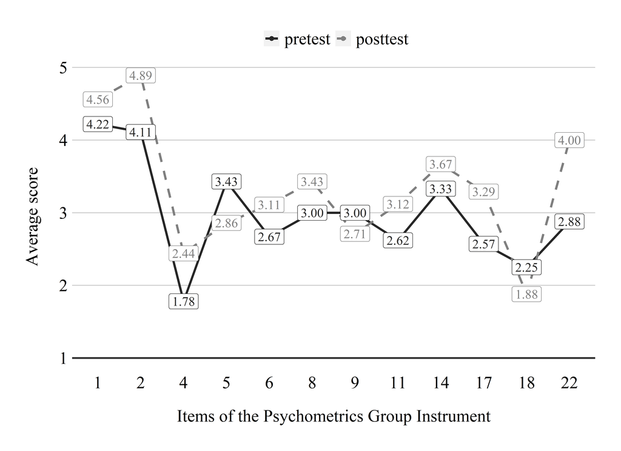

```r
items <- c(1, 2, 4, 5, 6, 8, 9, 11, 14, 17, 18, 22)
pretest <- c(4.22, 4.11, 1.78, 3.43, 2.67, 3.00,  # pretest means
             3.00, 2.62, 3.33, 2.57, 2.25, 2.88)
posttest <- c(4.56, 4.89, 2.44, 2.86, 3.11, 3.43,  # posttest means
              2.71, 3.12, 3.67, 3.29, 1.88, 4.00)

effect <- tibble(items, pretest, posttest)
effect <- effect %>%
  pivot_longer(
    cols = c(pretest, posttest),
    names_to = "pre_post",
    values_to = "mean"
  ) %>%
  mutate(pre_post = as_factor(pre_post),
         items = as_factor(items))

plot_effect <- ggplot(effect, aes(items, mean, group = pre_post, col = pre_post)) +
  geom_point(size = 2) +
  geom_line(size = 1.2, aes(linetype = pre_post)) +
  geom_label(aes(items, mean,
                 label = sprintf("%0.2f", round(mean, digits = 2))),
             show.legend = F,
             size = 5,
             family = "Times New Roman") +
  geom_hline(yintercept = 1, size = 1, colour = "#333333") +
  labs(x = "Items of the Psychometrics Group Instrument",
       y = "Average score") +
  theme(legend.position = "top",
        legend.title = element_blank(),
        legend.text = element_text(size = 19,
                                   color = "black",
                                   family = "Times New Roman"),
        axis.text.x = element_text(size = 19,
                                   colour = "black",
                                   family = "Times New Roman"),
        axis.text.y = element_text(size = 19,
                                   colour = "black",
                                   family = "Times New Roman"),
        plot.margin = margin(1, 1, 1, 1, "cm"),
        axis.title.x = element_text(size = 19,
                                    colour = "black",
                                    family = "Times New Roman",
                                    margin = margin(t = 20)),
        axis.title.y = element_text(size = 19,
                                    colour = "black",
                                    family = "Times New Roman",
                                    margin = margin(r = 20)),
        panel.grid.minor = element_blank(),
        panel.grid.major.y = element_line(color="#cbcbcb"),
        panel.grid.major.x = element_blank(),
        panel.background = element_blank(),
        axis.ticks = element_blank(),
        axis.line = element_blank()) +
  scale_color_manual(breaks = c("pretest", "posttest"),
                     values = c("grey15", "grey50")) +
  scale_linetype_manual(values = c("solid", "dashed"))
```

If you want to export the plot, you can use this code:

```r
ggsave("Figure_3.emf", plot = plot_effect,
       width = 9.50, height = 6.90)
```